# Module 5 - Matching (Answer Key)

ECON 526/593E

# Matching

**Click for Submission Instructions & Data**

Prepare your answers in R Markdown. Your submission should contain the exact same headings shown below along with your text and graphs, where appropriate, addressing all questions. When you knit your R Markdown script, use the following file naming convention for the html and Rmd documents you generate: lastname_module_N_homework.html (.Rmd) (replace "lastname" with your last name and "N" with the module number). Email your documents as attachments to ajc0056@mix.wvu.edu with the subject line "ECON 593 lastname Homework Module N". You can download the data for this module here (codebook [here](https://github.com/sejdemyr/ecls/blob/master/data-processed/ecls-codebook.txt)). It will specify when/where packages are needed.

Primary, secondary, and post-secondary education all lead to increased human capital, an important factor in driving long run economic growth, worker productivity, employment, innovation, and other important economic outcomes. The production of education takes many forms. For example, primary and secondary education markets contain public schools, schools operated by various religious faiths (the Catholic church, various fundamentalist religions, etc.), as well as private non-denominational organizations like charter schools. Because of the economic importance of education and human capital formation, research on the effectiveness of different forms of education is interesting and important.

Private Catholic schools represent a common alternative to public schools in many communities. A large body of economic research focuses on how different types of education, in particular Catholic versus public school education, affects educational outcomes. This research primarily focuses on grades, but some papers examine high school graduation rates and rates of college attendance.

This research faces a number of important econometric challenges. One key challenge stems from the fact that the decision to enroll a child in Catholic or public schools reflects parental choice and not random assignment. School enrollment decisions reflect many factors at the family and individual level. While public school attendance is free of charge, and financed by taxes, private education like attendance at a Catholic school requires paying tuition, making family income an important factor. Income may also affect educational outcomes independent of school choice, for example through tutoring, educational software, and other unobservable factors, making income a likely back door.

In a "dream" world, a team of economists could obtain a sample of 10,000 students and randomly assign them to either a Catholic school or a public school. In this situation, we could have more confidence in estimates of a casual treatment effect of school type on educational outcomes. However, for obvious reasons, this is not possible. Instead, education economists frequently use matching methods like Propensity Score Matching to come up with as-if random assignment of catholic school education to generate more plausible causal estimates. This homework applies matching methods to a data set containing information on school enrollment, grades, and family characteristics.

## Question 1

Summarize the main research question in the assignment and the application setting. Discuss why this causal inference approach is appropriate for this research question. (**2 Points**)

## Question 2

Describe the data analyzed, including general structure of the data set, the nature of the data, and any potential measurement issues. Discuss why this data set is appropriate for this causal inference method.

Read in the data using the above URL and save it in a file called `school`. Because the column (variable) names are not informative (the creators of this data set did not follow the principles of replicable research), change the names as follows (hint[^1]):

- "c5r2mtsc" : "math"
- "c5r2mtsc_std" : "math_std"
- "p5hmage" : "mom_age"
- "w3momed_hsb" : "mom_noCollege"
- "w3income" : "income"
- "catholic" : "catholic" (no change, this is just for completeness)

Tabulate the `catholic` variable. How many students in the sample attend a catholic school? Find the average standardized math test score for catholic school students and public school students (hint[^2]). What does this tell you? Interpret the numeric values in this table (hint[^3]). Finally, find the average for **each variable** using the `aggregate()` function (hint[^4]). (**2 points**)

```r
school <- read.csv("https://alexcardazzi.github.io/teaching/econ-593e/catholic1.csv", stringsAsFactors = FALSE)
colnames(school) <- c("math", "math_std", "mom_age", "mom_noCollege", "income", "catholic")

table(ifelse(school$catholic == 1, "catholic school", "public school"))
```

```
##
## catholic school   public school
##            1187            6332
```

```r
aggregate(school$math_std, list(ifelse(school$catholic == 1, "catholic school", "public school")), mean)
```

```
##           Group.1         x
## 1 catholic school 0.2480226
## 2   public school 0.1180608
```

```r
aggregate(school, list(ifelse(school$catholic == 1, "catholic school", "public school")), mean)
```

```
##           Group.1     math  math_std  mom_age mom_noCollege   income catholic
## 1 catholic school 52.91548 0.2480226 39.79191     0.2181971 87.61425        1
## 2   public school 51.65302 0.1180608 37.84523     0.4335123 62.95376        0
```

## Question 3

Describe the causal inference method used in this paper. Discuss the assumptions underlying the causal inference method used in the empirical analysis, including the conditional independence assumption (CIA). Include a discussion of threats to validity of the results in terms of causal inference. Make sure to discuss specific issues in school choice. (**2 points**)

## Question 4

Visualize the data using two plots. Plot the density of the standardized math scores for children who attend catholic school and for children who attend public school. Make each density line a different color to differentiate between the two. Use these colors throughout the rest of the assignment. Include two dashed vertical lines on the plot to visualize the means of the distributions (hint[^5]). Do a similar plot for `mom_age`. Remember, do not let the graph get cutoff and fix labels. (**2 points**)

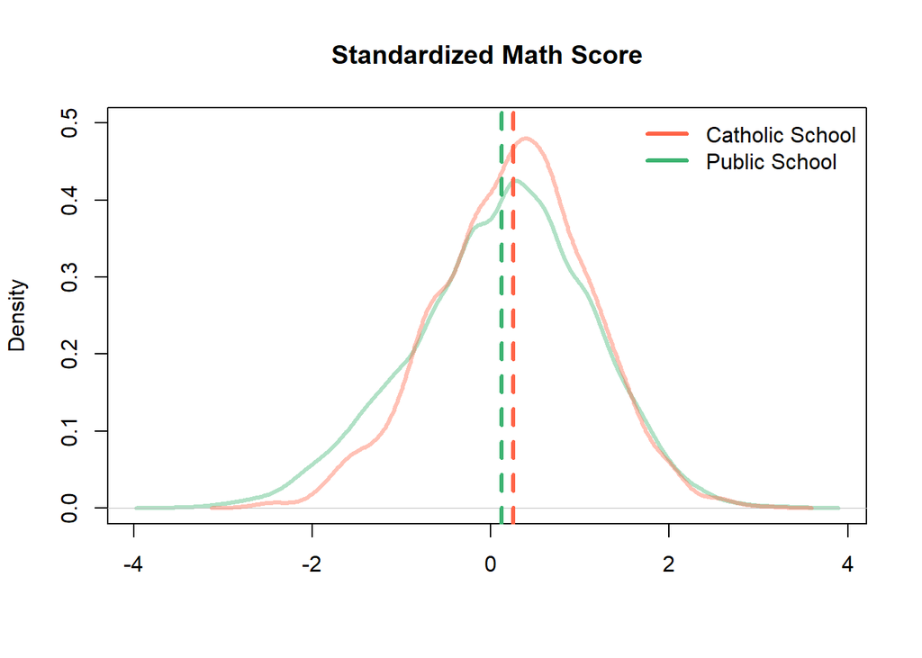

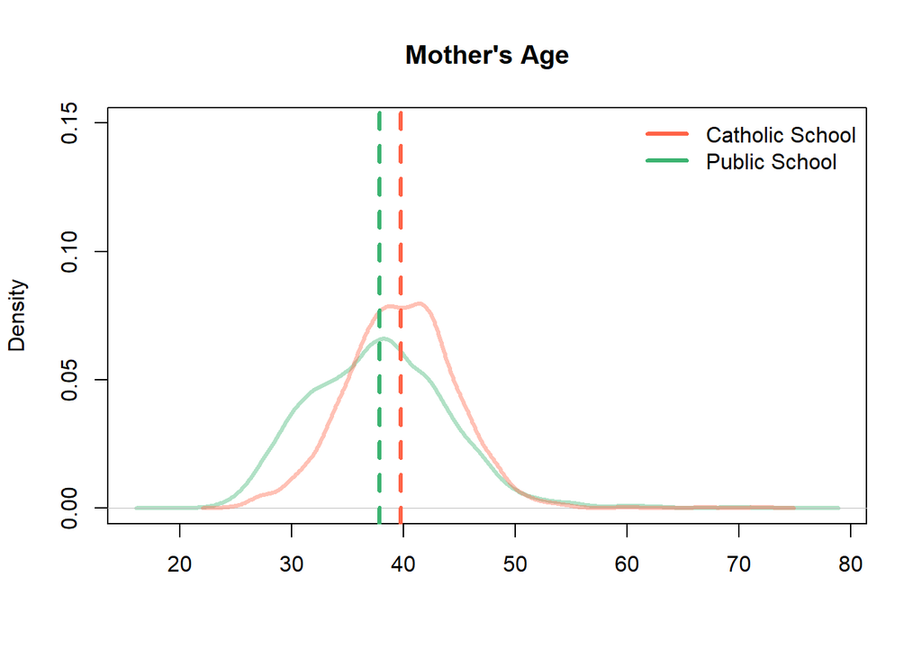

```r
library("scales")

plot(density(school$math_std[school$catholic == 0]), col = alpha("mediumseagreen", .4), lwd = 3, ylim = c(0, .5),
     xlab = "", main = "Standardized Math Score")
lines(density(school$math_std[school$catholic == 1]), col = alpha("tomato", .4), lwd = 3)
abline(v = c(mean(school$math_std[school$catholic == 1]),
             mean(school$math_std[school$catholic == 0])), col = c("tomato", "mediumseagreen"), lwd = 3, lty = 2)
legend(legend = c("Catholic School", "Public School"),
       col = c("tomato", "mediumseagreen"), lty = c(1, 1),
       "topright", bty = "n", lwd = 3)

plot(density(school$mom_age[school$catholic == 0]), col = alpha("mediumseagreen", .4), lwd = 3, ylim = c(0, .15),
     xlab = "", main = "Mother's Age")
lines(density(school$mom_age[school$catholic == 1]), col = alpha("tomato", .4), lwd = 3)
abline(v = c(mean(school$mom_age[school$catholic == 1]),
             mean(school$mom_age[school$catholic == 0])), col = c("tomato", "mediumseagreen"), lwd = 3, lty = 2)
legend(legend = c("Catholic School", "Public School"),
       col = c("tomato", "mediumseagreen"), lty = c(1, 1),
       "topright", bty = "n", lwd = 3)
```

## Question 5

Using `mom_age`, `mom_noCollege` and `income`, run a [logistic regression](https://stats.idre.ucla.edu/r/dae/logit-regression/) to generate propensity scores for each student (hint[^6]). Save this regression as `reg_ps`. Use `stargazer` to report the coefficients of the regression used. Assign each observation its respective propensity score.

```r
library("stargazer")

reg_ps <- glm(catholic ~ mom_age + mom_noCollege + income,
            family = "binomial", data = school)
stargazer(reg_ps, type = "text")


school$ps <- reg_ps$fitted.values
```

```
##
## =============================================
##                       Dependent variable:
##                   ---------------------------
##                            catholic
## ---------------------------------------------
## mom_age                    0.033***
##                             (0.006)
##
## mom_noCollege              -0.660***
##                             (0.080)
##
## income                     0.007***
##                             (0.001)
##
## Constant                   -3.302***
##                             (0.227)
##
## ---------------------------------------------
## Observations                 7,519
## Log Likelihood            -3,090.400
## Akaike Inf. Crit.          6,188.801
## =============================================
## Note:             *p<0.1; **p<0.05; ***p<0.01
```

Install the package `MatchIt`. You can do this in your console, and then you will never have to re-install. Remember to load the package with `library("MatchIt")`.

Use the function `matchit()` to find matches for the data (hint[^7]). Save the result as `the_match`. Next, use the `match.data()` function to generate a matched dataset and call this object `school_match`. See the vignette for `MatchIt` [here](https://cran.r-project.org/web/packages/MatchIt/vignettes/MatchIt.html) for help with this.

```r
#install.packages("MatchIt")
library("MatchIt")
matchit(catholic ~ mom_age + mom_noCollege + income,
        method = "nearest", data = school) -> the_match

school_match <- match.data(the_match)
```

Covariate balance represents an important part of PSM. To visualize the success of the matching in terms of covariate balance, generate three plots. The first two plots should be in a 1x2 panel. Find the mean `mom_age` by propensity score and school enrollment (hint[^8]) for the full sample. Save this as `k` as it will just be a temporary variable. In the first panel, plot the average propensity score on the x axis and mother's age on the y axis using the data in `k`. Make sure to color the points by whether the data pertains to catholic school children! In the second panel, do the same thing for the matched sample. For the last plot (in a panel by itself), plot the density of `mom_age` for kids attending public school in the full sample, the density of `mom_age` for kids attending catholic school in the full sample, and the density of `mom_age` for kids attending public school in the *matched* sample. Make this last density a dashed line instead of solid. For all plots, do not forget to label axes and include legends.

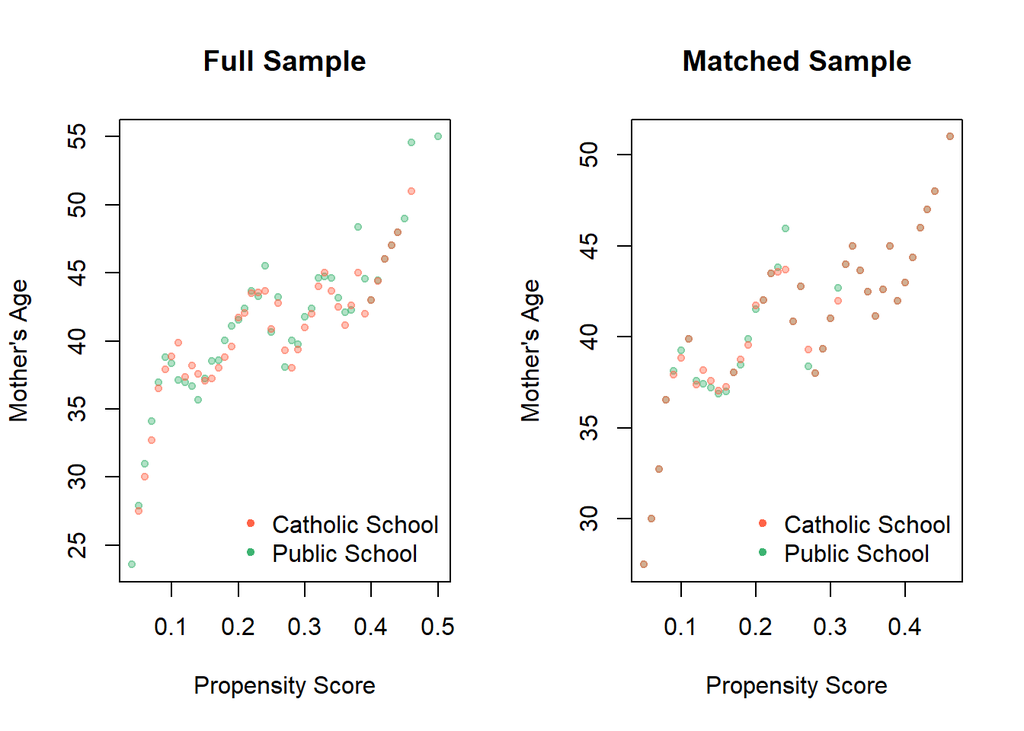

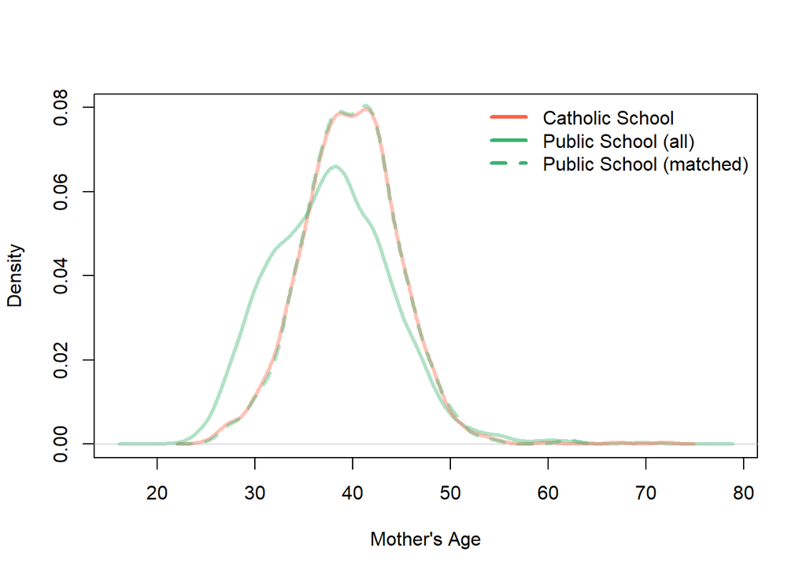

```r
par(mfrow = c(1, 2))

k <- aggregate(school$mom_age, list(round(school$ps, 2), school$catholic), mean)
plot(k$Group.1, k$x, col = alpha(ifelse(k$Group.2 == 1, "tomato", "mediumseagreen"), .4), pch = 20,
     xlab = "Propensity Score", ylab = "Mother's Age", main = "Full Sample")
legend(legend = c("Catholic School", "Public School"),
       col = c("tomato", "mediumseagreen"),
       "bottomright", bty = "n", pch = 20)

k <- aggregate(school_match$mom_age, list(round(school_match$ps, 2), school_match$catholic), mean)
plot(k$Group.1, k$x, col = alpha(ifelse(k$Group.2 == 1, "tomato", "mediumseagreen"), .4), pch = 20,
     xlab = "Propensity Score", ylab = "Mother's Age", main = "Matched Sample")
legend(legend = c("Catholic School", "Public School"),
       col = c("tomato", "mediumseagreen"),
       "bottomright", bty = "n", pch = 20)


par(mfrow = c(1, 1))
plot(density(school$mom_age[school$catholic == 0]), col = alpha("mediumseagreen", .4), ylim = c(0, .08), lwd = 3,
     xlab = "Mother's Age", main = "")
lines(density(school$mom_age[school$catholic == 1]), col = alpha("tomato", .4), lwd = 3)
lines(density(school_match$mom_age[school_match$catholic == 0]), col = alpha("mediumseagreen", .4),lwd = 3, lty = 2)
legend(legend = c("Catholic School", "Public School (all)", "Public School (matched)"),
       col = c("tomato", "mediumseagreen", "mediumseagreen"), lty = c(1, 1, 2),
       "topright", bty = "n", lwd = 3)
```

Finally, estimate the effect of attending catholic school on standardized test scores. First, using the entire data set (`school`), run a regression to explain variation in standardized test scores (`math_std`) using only whether or not a child attends catholic school (`catholic`). Run a second regression that includes the controls `mom_age`, `mom_noCollege`, and `income`. Rerun these two regressions with the matched dataset (`school_match`). Feed all four regressions into a single `stargazer` command. In `stargazer`, omit the control from the output, omit `f` and `ser`, and add lines telling the reader which sample the regression uses and if controls are included. (**2 points**)

```r
reg1 <- lm(math_std ~ catholic, data = school)
reg2 <- lm(math_std ~ catholic + mom_age + mom_noCollege + income, data = school)
reg3 <- lm(math_std ~ catholic, data = school_match)
reg4 <- lm(math_std ~ catholic + mom_age + mom_noCollege + income, data = school_match)


stargazer(reg1, reg2, reg3, reg4, type = "text",
          omit.stat = c("f", "ser"),
          omit = c("mom", "income"),
          add.lines = list(c("Sample", "Full", "Full", "Matched", "Matched"),
                           c("Controls?", "No", "Yes", "No", "Yes"))
          )
```

```
===================================================
                      Dependent variable:
             --------------------------------------
                            math_std
               (1)       (2)       (3)       (4)
---------------------------------------------------
catholic     0.130*** -0.098*** -0.129*** -0.129***
             (0.031)   (0.029)   (0.037)   (0.035)

Constant     0.118*** -0.468*** 0.377***  -0.411***
             (0.012)   (0.070)   (0.026)   (0.147)

---------------------------------------------------
Sample         Full     Full     Matched   Matched
Controls?       No       Yes       No        Yes
Observations  7,519     7,519     2,374     2,374
R2            0.002     0.141     0.005     0.085
Adjusted R2   0.002     0.140     0.005     0.083
===================================================
Note:                   *p<0.1; **p<0.05; ***p<0.01
```

## Question 6

Discuss and interpret the *signs* and significance of the coefficient estimates from `reg_ps` (hint[^9]). What do these signs mean in practical terms? Discuss the success/failure of the matching process based on the graphs. Make sure to include a discussion of the textual output as well as the plots. Finally, discuss and interpret the regression results in your final `stargazer` output. Be sure to discuss the relationship between the parameter estimate on the *catholic* treatment variable in model 1 and the unconditional sample means on the standardized test score variable by type of school reported in Question 2. (2 points)

## Question 7

Compare your results and this application to the PSM example on the impact of the NSW Job Training Program in the Mixtape chapter on matching. Is this application better or worse than the one in the chapter in terms of the use of Matching methods? How does this application, and these results, differ? For example, discuss the relative strength of assumptions, effect size, etc. (2 points)

## Question 8

Do you believe the result above is credibly causal? Are the sign and magnitude plausible? Explain why or why not. (2 points)

[^1]: use the `colnames()` function to do this. Resource link [here](https://stackoverflow.com/questions/6081439/changing-column-names-of-a-data-frame).
[^2]: use the `aggregate()` function to do this.
[^3]: Keep in mind this variable has been "standardized" and has a mean of 0 and standard deviation of 1. Transforming a variable to a standardized value requires subtracting the sample mean from each observation and dividing this difference by the sample standard deviation. Researchers standardize grades to make them more comparable across schools.
[^4]: Check out the first example [here](https://www.r-bloggers.com/2018/07/how-to-aggregate-data-in-r/)
[^5]: Check out this [link](http://www.sthda.com/english/wiki/abline-r-function-an-easy-way-to-add-straight-lines-to-a-plot-using-r-software#add-a-vertical-line) for help.
[^6]: When you save a regression object in R, it is saved as a list. Therefore, you can assess things from the regression, whether that be coefficients, residuals, or fitted values.
[^7]: Use `method = "nearest"`, and do *not* use the `distance` arguement.
[^8]: round the propensity score to the nearest hundreth (0.01). Example: `round(.1234, 2) == .12`
[^9]: Coefficients from logistic regressions cannot be interpreted in the same way as OLS.